[figure not shown]

### *Dr. Oldemar Rodríguez R.*

## Calibración y Selección de Modelos

- Para calibrar un modelo y luego seleccionar el más adecuado para una tabla de datos dada se deben escoger los mejores valores para los parámetros del modelo dado. Por ejemplo, para un modelo descriptivo, de manera que maximicen la Inercia Inter-Clases, o para un modelo predictivo, escoger los parámetros que minimicen el error global o maximicen el área bajo la curva ROC.
- Para conocer todos los parametros y salidas de un método en R se hace con el comando signo de pregunta “?”, por ejemplo: ?kmeans para ver la ayuda del método de las k-medias o ?rpart para ver la ayuda sobre el método rpart para generar árboles de decisión, no olvide cargar el paquete respectivo antes de ejecutar el comando de ayuda.

## Modelos Predictivos

### Calibrando el método “Máquinas Vectoriales de Soporte” para los datos de Scoring de Crédito

- Para esto: generamos un solo archivo “MuestraCredito5000.csv” a partir de los archivos “MuestraTestCredito2500.csv” y “MuestraAprendizajeCredito2500.csv”.
- En el caso del Scoring de Crédito lo que más interesa es detectar a los NO pagadores, por esa razón ejecutaremos 5 veces la validación cruzada usando 10 grupos. En cada paso de la valización cruzada vamos sumando los no pagadores detectados, luego para cada ejecución de la valizadación cruzada almacenamos la detección de los no pagadores en una entrada del vector respectivo al método para luego hacer un gráfico comparativo.
- Como se puede verificar en el gráfico el mejor resultado se obtiene usando un Kernel Linear, muy similar a Radial.

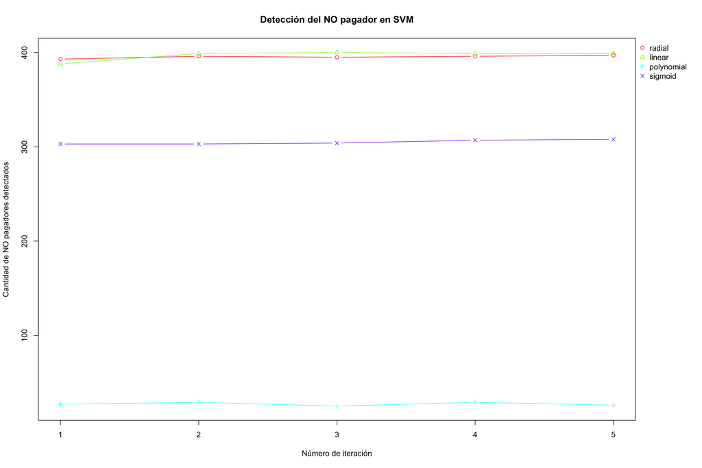

```r
library(traineR)
library(caret)
setwd("~/Google Drive/MDCurso/Datos")
datos <- read.csv("MuestraCredito5000V2.csv",sep = ";",header=T)
# Recodifica las variables como categóricas ordinales
datos$IngresoNeto <- factor(datos$IngresoNeto,ordered = TRUE)
datos$CoefCreditoAvaluo <- factor(datos$CoefCreditoAvaluo,ordered = TRUE)
dim(datos)
# Hay 705 malos pagadores
summary(datos)
numero.filas <- nrow(datos)
cantidad.validacion.cruzada <- 5
cantidad.grupos <- 10

deteccion.no.radial <- c()
deteccion.no.linear <- c()
deteccion.no.polynomial <- c()
deteccion.no.sigmoid <- c()

for(i in 1:cantidad.validacion.cruzada){
  grupos  <- createFolds(1:numero.filas, cantidad.grupos)  # Crea los 10 grupos
  no.radial <- 0
  no.linear <- 0
  no.polynomial <- 0
  no.sigmoid <- 0

  # Este ciclo es el que hace 'cross-validation' (validación cruzada) con 10
  # grupos (Folds)
  for(k in 1:cantidad.grupos) {
    muestra <- grupos[[k]]  # Por ser una lista requiere de doble paréntesis
    ttesting <- datos[muestra, ]
    taprendizaje <- datos[-muestra, ]

    modelo <- train.svm(BuenPagador ~ ., data = taprendizaje, kernel = "radial", probability = FALSE)
    prediccion <- predict(modelo, ttesting)
    MC <- confusion.matrix(ttesting, prediccion)
    no.radial <- no.radial + MC["No", "No"] # Detección de los NO Pagadores

    modelo <- train.svm(BuenPagador ~ ., data = taprendizaje, kernel = "linear", probability = FALSE)
    prediccion <- predict(modelo, ttesting)
    MC <- confusion.matrix(ttesting, prediccion)
    no.linear <- no.linear + MC["No", "No"] # Detección de los NO Pagadores

    modelo <- train.svm(BuenPagador ~ ., data = taprendizaje, kernel = "polynomial", probability = FALSE)
    prediccion <- predict(modelo, ttesting)
    MC <- confusion.matrix(ttesting, prediccion)
    no.polynomial <- no.polynomial + MC["No", "No"] # Detección de los NO Pagadores

    modelo <- train.svm(BuenPagador ~ ., data = taprendizaje, kernel = "sigmoid", probability = FALSE)
    prediccion <- predict(modelo, ttesting)
    MC <- confusion.matrix(ttesting, prediccion)
    no.sigmoid <- no.sigmoid + MC["No", "No"] # Detección de los NO Pagadores
  }

  deteccion.no.radial[i] <- no.radial
  deteccion.no.linear[i] <- no.linear
  deteccion.no.polynomial[i] <- no.polynomial
  deteccion.no.sigmoid[i] <- no.sigmoid
}

resultados <- data.frame("radial"     = deteccion.no.radial,
                         "linear"     = deteccion.no.linear,
                         "polynomial" = deteccion.no.polynomial,
                         "sigmoid"    = deteccion.no.sigmoid) # Preparamos los datos

par(oma=c(0, 0, 0, 5)) # Hace espacio para la leyenda

matplot(resultados, type="b", lty = 1, lwd = 1, pch = 1:ncol(resultados),
        main = "Detección del NO pagador en SVM",
        xlab = "Número de iteración",
        ylab = "Cantidad de NO pagadores detectados",
        col = rainbow(ncol(resultados)))
legend(par('usr')[2], par('usr')[4], legend = colnames(resultados),bty='n', xpd=NA,
       pch=1:ncol(resultados), col = rainbow(ncol(resultados))) # La leyenda
```

### Seleccionando el mejor método para los datos de Scoring de Crédito

Para este ejemplo se supone que todos los métodos que usaremos ya fueron calibrados (aunque en realidad solo hemos calibrado la Máquinas Vectoriales de Soporte en el ejemplo anterior). Una vez calibrados los pondremos a competir usando Validación Cruzada para ver cuál de los métodos detecta mejor a los malos pagadores. También podría hacerse seleccionando el método que minimice el Error Global de detección, o idealmente hacer ambas cosas para luego tomar la decisión sobre el método elegido basado en ambos criterios. Eso sí, es mejor no hacer ambas cosas en el mismo proceso de Validación Cruzada, pues podría ser que un método maximice la detección de los NO pagadores y sea otro método el que minimice el Error Global. El mejor método, según el siguiente gráfico, está entre los métodos **KNN**, **XGBoosting** y **Bosques Aleatorios** pues son los que detentan mayor cantidad de **NO**.

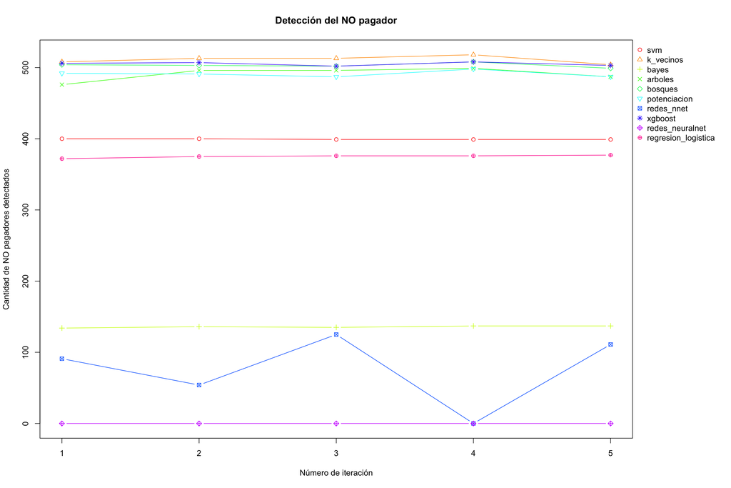

```r
library(caret)
library(traineR)
setwd("~/Google Drive/MDCurso/Datos")
datos <- read.csv("MuestraCredito5000V2.csv",sep = ";",header=T)
# Recodifica las variables como categóricas ordinales
datos$IngresoNeto <- factor(datos$IngresoNeto,ordered = TRUE)
datos$CoefCreditoAvaluo <- factor(datos$CoefCreditoAvaluo,ordered = TRUE)
dim(datos)
# Hay 705 malos pagadores
summary(datos)

numero.filas <- nrow(datos)
cantidad.validacion.cruzada <- 5
cantidad.grupos <- 10

deteccion.no.svm <- c()
deteccion.no.knn <- c()
deteccion.no.bayes <- c()
deteccion.no.arbol <- c()
deteccion.no.bosque <- c()
deteccion.no.potenciacion <- c()
deteccion.no.red <- c()
deteccion.no.xgboost <- c()
deteccion.no.red.neu <- c()
deteccion.no.glm <- c()

# Validación cruzada 5 veces
for (i in 1:cantidad.validacion.cruzada) {
  grupos <- createFolds(1:numero.filas, cantidad.grupos) # Crea los 10 grupos
  no.svm <- 0
  no.knn <- 0
  no.bayes <- 0
  no.arbol <- 0
  no.bosque <- 0
  no.potenciacion <- 0
  no.red <- 0
  no.xg  <- 0
  no.red.neu <- 0
  no.glm <- 0

  # Este ciclo es el que hace validación cruzada con 10 grupos
  for (k in 1:cantidad.grupos) {
    muestra <- grupos[[k]] # Por ser una lista requiere de doble paréntesis
    ttesting <- datos[muestra, ]
    ttraining <- datos[-muestra, ]

    modelo <- train.svm(BuenPagador ~ ., data = ttraining, kernel = "linear", probability = FALSE)
    prediccion <- predict(modelo, ttesting)
    MC <- confusion.matrix(ttesting, prediccion)
    no.svm <- no.svm + MC["No", "No"] # Detección de los No Pagadores

    modelo <- train.knn(BuenPagador ~ ., data = ttraining, kmax = 37)
    prediccion <- predict(modelo, ttesting)
    MC <- confusion.matrix(ttesting, prediccion)
    no.knn <- no.knn + MC["No", "No"] # Detección de los No Pagadores

    modelo <- train.bayes(BuenPagador ~ ., data = ttraining)
    prediccion <- predict(modelo, ttesting)
    MC <- confusion.matrix(ttesting, prediccion)
    no.bayes <- no.bayes + MC["No", "No"] # Detección de los No Pagadores

    modelo = train.rpart(BuenPagador ~ ., data = ttraining)
    prediccion <- predict(modelo, ttesting)
    MC <- confusion.matrix(ttesting, prediccion)
    no.arbol <- no.arbol + MC["No", "No"] # Detección de los No Pagadores

    modelo <- train.randomForest(BuenPagador ~ ., data = ttraining)
    prediccion <- predict(modelo, ttesting)
    MC <- confusion.matrix(ttesting, prediccion)
    no.bosque <- no.bosque + MC["No", "No"] # Detección de los No Pagadores

    modelo <- train.ada(BuenPagador ~ ., data = ttraining, iter = 20, nu = 1, type = "discrete")
    prediccion <- predict(modelo, ttesting)
    MC <- confusion.matrix(ttesting, prediccion)
    no.potenciacion <- no.potenciacion + MC["No", "No"] # Detección de los No Pagadores

    modelo <- train.nnet(BuenPagador ~ ., data = ttraining, size = 100, MaxNWts = 5000, rang = 0.01,
               decay = 5e-4, maxit = 45, trace = TRUE)
    prediccion <- predict(modelo, ttesting)
    MC <- confusion.matrix(ttesting, prediccion)
    no.red <- no.red + MC["No", "No"] # Detección de los No Pagadores

    modelo <- train.xgboost(BuenPagador ~ ., data = ttraining, nrounds = 79,
                        print_every_n = 10, maximize = F , eval_metric = "error")
    prediccion <- predict(modelo, ttesting)
    MC <- confusion.matrix(ttesting, prediccion)
    no.xg <- no.xg + MC["No", "No"] # Detección de los No Pagadores

    modelo <- train.neuralnet(BuenPagador ~., data = ttraining, hidden = c(8,6,4),
                          linear.output = FALSE, threshold = 0.5, stepmax = 1e+06)
    prediccion <- predict(modelo, ttesting)
    MC <- confusion.matrix(ttesting, prediccion)
    no.red.neu <- no.red.neu + MC["No", "No"] # Detección de los No Pagadores

    modelo <- train.glm(BuenPagador ~ ., data = ttraining)
    prediccion <- predict(modelo, ttesting)
    MC <- confusion.matrix(ttesting, prediccion)
    no.glm <- no.glm + MC["No", "No"] # Detección de los No Pagadores
  }
  deteccion.no.svm[i] <- no.svm
  deteccion.no.knn[i] <- no.knn
  deteccion.no.bayes[i] <- no.bayes
  deteccion.no.arbol[i] <- no.arbol
  deteccion.no.bosque[i] <- no.bosque
  deteccion.no.potenciacion[i] <- no.potenciacion
  deteccion.no.red[i] <- no.red
  deteccion.no.xgboost[i] <- no.xg
  deteccion.no.red.neu[i] <- no.red.neu
  deteccion.no.glm[i] <- no.glm
}

resultados <- data.frame("svm" = deteccion.no.svm,
                         "k_vecinos" = deteccion.no.knn,
                         "bayes" = deteccion.no.bayes,
                         "arboles" = deteccion.no.arbol,
                         "bosques" = deteccion.no.bosque,
                         "potenciacion" = deteccion.no.potenciacion,
                         "redes_nnet" = deteccion.no.red,
                         "xgboost" = deteccion.no.xgboost,
                         "redes_neuralnet" = no.red.neu,
                         "regresion_logistica" = deteccion.no.glm)

par(oma=c(0, 0, 0, 8)) # Hace espacio para la leyenda

matplot(resultados, type="b", lty = 1, lwd = 1, pch = 1:ncol(resultados),
        main = "Detección del NO pagador",
        xlab = "Número de iteración",
        ylab = "Cantidad de NO pagadores detectados",
        col = rainbow(ncol(resultados)))
legend(par('usr')[2], par('usr')[4], legend = colnames(resultados),bty='n', xpd=NA,
       pch=1:ncol(resultados), col = rainbow(ncol(resultados))) # La leyenda
```

- Ahora los vamos a hacer seleccionando el método que minimice el Error Global de detección. Se deben escoger el método con mayor detección del **NO** pero que a la vez minimize el error global. Como puede verse en el gráfico abajo, el menor error lo tiene el método **Bosques Aleatorios** y como es un de los métodos que más detecta en **NO** este es el método elejido para este juego de datos.

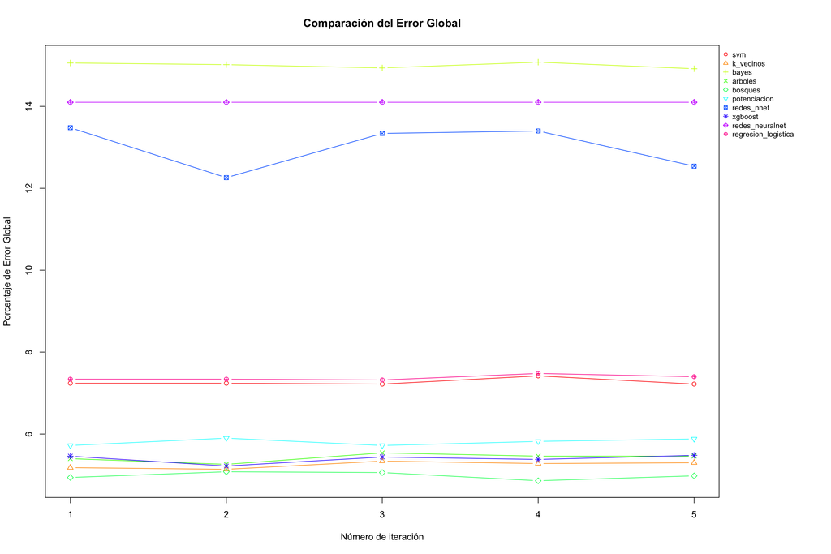

```r
library(caret)
library(traineR)
setwd("~/Google Drive/MDCurso/Datos")
datos <- read.csv("MuestraCredito5000V2.csv",sep = ";",header=T)
# Recodifica las variables como categóricas ordinales
datos$IngresoNeto <- factor(datos$IngresoNeto,ordered = TRUE)
datos$CoefCreditoAvaluo <- factor(datos$CoefCreditoAvaluo,ordered = TRUE)
dim(datos)
# Hay 705 malos pagadores
summary(datos)
numero.filas <- nrow(datos)
cantidad.validacion.cruzada <- 5
cantidad.grupos <- 10

deteccion.error.svm <- c()
deteccion.error.knn <- c()
deteccion.error.bayes <- c()
deteccion.error.arbol <- c()
deteccion.error.bosque <- c()
deteccion.error.potenciacion <- c()
deteccion.error.red <- c()
deteccion.error.xgboost <- c()
deteccion.error.red.neu <- c()
deteccion.error.glm <- c()

# Validación cruzada 5 veces
for (i in 1:cantidad.validacion.cruzada) {
  grupos <- createFolds(1:numero.filas, cantidad.grupos) # Crea los 10 grupos
  error.svm <- 0
  error.knn <- 0
  error.bayes <- 0
  error.arbol <- 0
  error.bosque <- 0
  error.potenciacion <- 0
  error.red <- 0
  error.xg  <- 0
  error.red.neu <- 0
  error.glm <- 0

  # Este ciclo es el que hace validación cruzada con 10 grupos
  for (k in 1:cantidad.grupos) {
    muestra <- grupos[[k]] # Por ser una lista requiere de doble paréntesis
    ttesting <- datos[muestra, ]
    ttraining <- datos[-muestra, ]

    modelo <- train.svm(BuenPagador ~ ., data = ttraining, kernel = "linear", probability = FALSE)
    prediccion <- predict(modelo, ttesting)
    MC <- confusion.matrix(ttesting, prediccion)
    # Cálculo del ERROR
    error.svm<-error.svm+(1-(sum(diag(MC)))/sum(MC))*100

    modelo <- train.knn(BuenPagador ~ ., data = ttraining, kmax = 37)
    prediccion <- predict(modelo, ttesting)
    MC <- confusion.matrix(ttesting, prediccion)
    # Cálculo del ERROR
    error.knn <- error.knn+(1-(sum(diag(MC)))/sum(MC))*100

    modelo <- train.bayes(BuenPagador ~ ., data = ttraining)
    prediccion <- predict(modelo, ttesting)
    MC <- confusion.matrix(ttesting, prediccion)
    # Cálculo del ERROR
    error.bayes <- error.bayes+(1-(sum(diag(MC)))/sum(MC))*100

    modelo = train.rpart(BuenPagador ~ ., data = ttraining)
    prediccion <- predict(modelo, ttesting)
    MC <- confusion.matrix(ttesting, prediccion)
    # Cálculo del ERROR
    error.arbol <- error.arbol+(1-(sum(diag(MC)))/sum(MC))*100

    modelo <- train.randomForest(BuenPagador ~ ., data = ttraining)
    prediccion <- predict(modelo, ttesting)
    MC <- confusion.matrix(ttesting, prediccion)
    # Cálculo del ERROR
    error.bosque <- error.bosque+(1-(sum(diag(MC)))/sum(MC))*100

    modelo <- train.ada(BuenPagador ~ ., data = ttraining, iter = 20, nu = 1, type = "discrete")
    prediccion <- predict(modelo, ttesting)
    MC <- confusion.matrix(ttesting, prediccion)
    # Cálculo del ERROR
    error.potenciacion <- error.potenciacion+(1-(sum(diag(MC)))/sum(MC))*100

    modelo <- train.nnet(BuenPagador ~ ., data = ttraining, size = 100, MaxNWts = 5000, rang = 0.01,
               decay = 5e-4, maxit = 45, trace = TRUE)
    prediccion <- predict(modelo, ttesting)
    MC <- confusion.matrix(ttesting, prediccion)
     # Cálculo del ERROR
    error.red <- error.red+(1-(sum(diag(MC)))/sum(MC))*100

    modelo <- train.xgboost(BuenPagador ~ ., data = ttraining, nrounds = 79,
                        print_every_n = 10, maximize = F , eval_metric = "error")
    prediccion <- predict(modelo, ttesting)
    MC <- confusion.matrix(ttesting, prediccion)
     # Cálculo del ERROR
    error.xg <- error.xg+(1-(sum(diag(MC)))/sum(MC))*100

    modelo <- train.neuralnet(BuenPagador ~., data = ttraining, hidden = c(8,6,4),
                          linear.output = FALSE, threshold = 0.5, stepmax = 1e+06)
    prediccion <- predict(modelo, ttesting)
    MC <- confusion.matrix(ttesting, prediccion)
    # Cálculo del ERROR
    error.red.neu <- error.red.neu+(1-(sum(diag(MC)))/sum(MC))*100

    modelo <- train.glm(BuenPagador ~ ., data = ttraining)
    prediccion <- predict(modelo, ttesting)
    MC <- confusion.matrix(ttesting, prediccion)
    # Cálculo del ERROR
    error.glm <- error.glm+(1-(sum(diag(MC)))/sum(MC))*100

  }
  deteccion.error.svm[i] <- error.svm/cantidad.grupos
  deteccion.error.knn[i] <- error.knn/cantidad.grupos
  deteccion.error.bayes[i] <- error.bayes/cantidad.grupos
  deteccion.error.arbol[i] <- error.arbol/cantidad.grupos
  deteccion.error.bosque[i] <- error.bosque/cantidad.grupos
  deteccion.error.potenciacion[i] <- error.potenciacion/cantidad.grupos
  deteccion.error.red[i] <- error.red/cantidad.grupos
  deteccion.error.xgboost[i] <- error.xg/cantidad.grupos
  deteccion.error.red.neu[i] <- error.red.neu/cantidad.grupos
  deteccion.error.glm[i] <- error.glm/cantidad.grupos
}

resultados <- data.frame("svm" = deteccion.error.svm,
                         "k_vecinos" = deteccion.error.knn,
                         "bayes" = deteccion.error.bayes,
                         "arboles" = deteccion.error.arbol,
                         "bosques" = deteccion.error.bosque,
                         "potenciacion" = deteccion.error.potenciacion,
                         "redes_nnet" = deteccion.error.red,
                         "xgboost" = deteccion.error.xgboost,
                         "redes_neuralnet" = deteccion.error.red.neu,
                         "regresion_logistica" = deteccion.error.glm)

par(oma=c(0, 0, 0, 8)) # Hace espacio para la leyenda
matplot(resultados, type="b", lty = 1, lwd = 1, pch = 1:ncol(resultados),
        main = "Comparación del Error Global",
        xlab = "Número de iteración",
        ylab = "Porcentaje de Error Global",
        col = rainbow(ncol(resultados)))
legend(par('usr')[2], par('usr')[4], legend = colnames(resultados),bty='n', xpd=NA, cex = 0.8,
       pch=1:ncol(resultados), col = rainbow(ncol(resultados))) # La leyenda
```

### *Nota:* Sería mejor unir los dos códigos anteriores en uno solo, pues tal y como está se repite las construcción de los modelos innecesariamente. Se hace así para efectos de simplificar el código de manera que sea más fácil la comprensión del mismo, pero para problemas reales deben unirse pues podría tomar mucho tiempo.